# Youtube Likes prediction

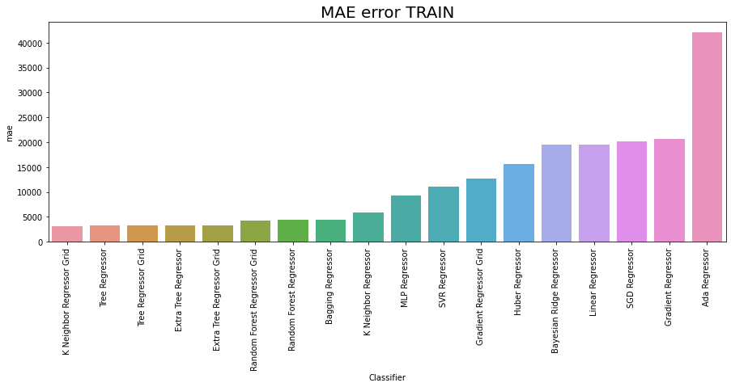

```python
plt.figure(figsize=(15,5))
a = scores_train.sort_values(by = 'mae')
p = sns.barplot(x = a.Classifier, y = a.mae)
p = plt.xticks(rotation=90)
plt.title("MAE error TRAIN", size=20)
```

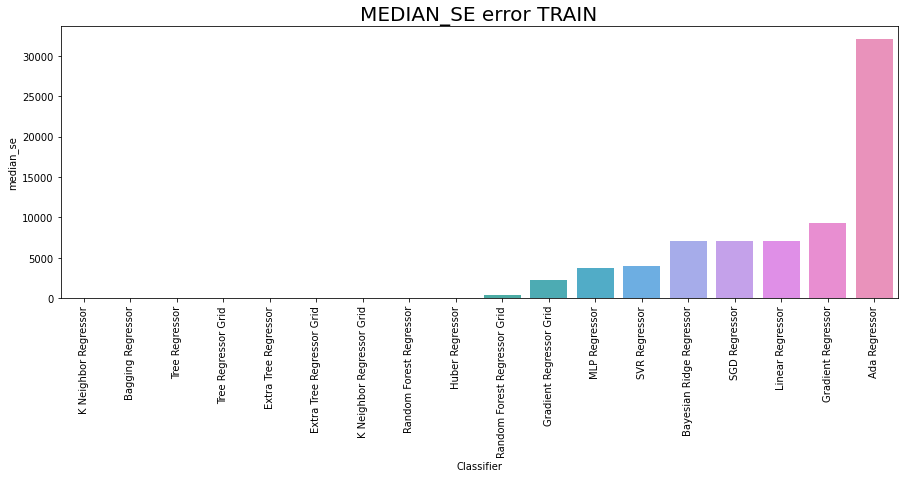

```python
plt.figure(figsize=(15,5))
a = scores_train.sort_values(by = 'median_se')
p = sns.barplot(x = a.Classifier, y = a.median_se)
p = plt.xticks(rotation=90)
plt.title("MEDIAN_SE error TRAIN", size=20)
```

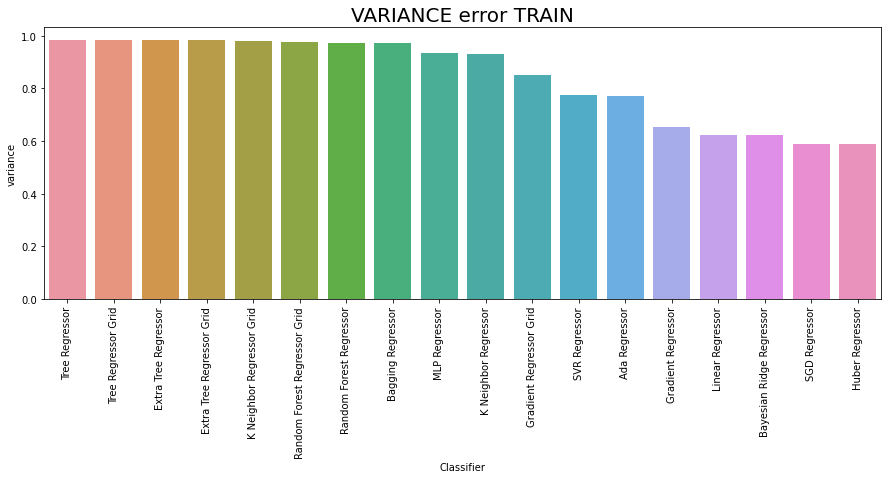

```python
plt.figure(figsize=(15,5))
a = scores_train.sort_values(by = 'variance', ascending = False)
p = sns.barplot(x = a.Classifier, y = a.variance)
p = plt.xticks(rotation=90)
plt.title("VARIANCE error TRAIN", size=20)
```

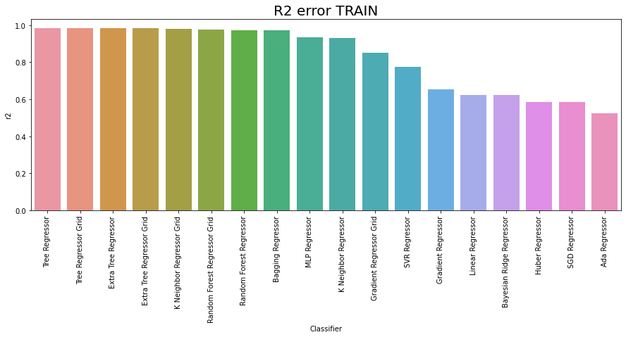

```python
plt.figure(figsize=(15,5))
a = scores_train.sort_values(by = 'r2', ascending = False)
p = sns.barplot(x = a.Classifier, y = a.r2)
p = plt.xticks(rotation=90)
plt.title("R2 error TRAIN", size=20)
```

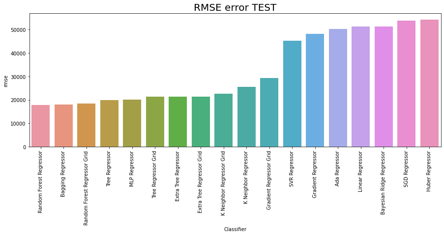

```python
plt.figure(figsize=(15,5))
a = scores_test.sort_values(by = 'rmse')
p = sns.barplot(x = a.Classifier, y = a.rmse)
p = plt.xticks(rotation=90)
plt.title("RMSE error TEST", size=20)
```

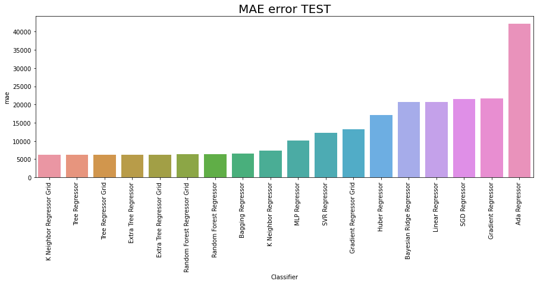

```python
plt.figure(figsize=(15,5))
a = scores_test.sort_values(by = 'mae')
p = sns.barplot(x = a.Classifier, y = a.mae)
p = plt.xticks(rotation=90)
plt.title("MAE error TEST", size=20)
```

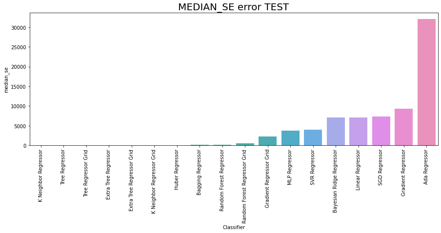

```python
plt.figure(figsize=(15,5))
a = scores_test.sort_values(by = 'median_se')
p = sns.barplot(x = a.Classifier, y = a.median_se)
p = plt.xticks(rotation=90)
plt.title("MEDIAN_SE error TEST", size=20)
```

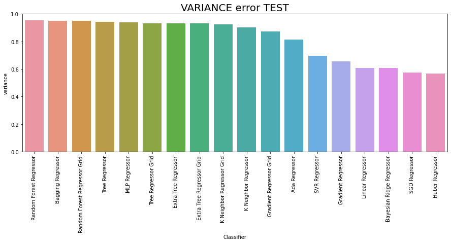

```python
plt.figure(figsize=(15,5))
a = scores_test.sort_values(by = 'variance', ascending = False)
p = sns.barplot(x = a.Classifier, y = a.variance)
p = plt.xticks(rotation=90)
plt.title("VARIANCE error TEST", size=20)
```

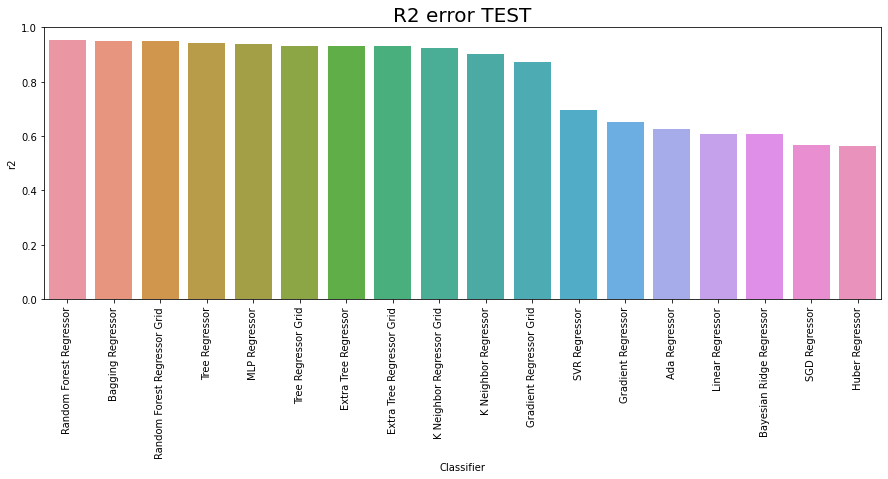

```python
plt.figure(figsize=(15,5))
a = scores_test.sort_values(by = 'r2', ascending = False)
p = sns.barplot(x = a.Classifier, y = a.r2)
p = plt.xticks(rotation=90)
plt.title("R2 error TEST", size=20)
```

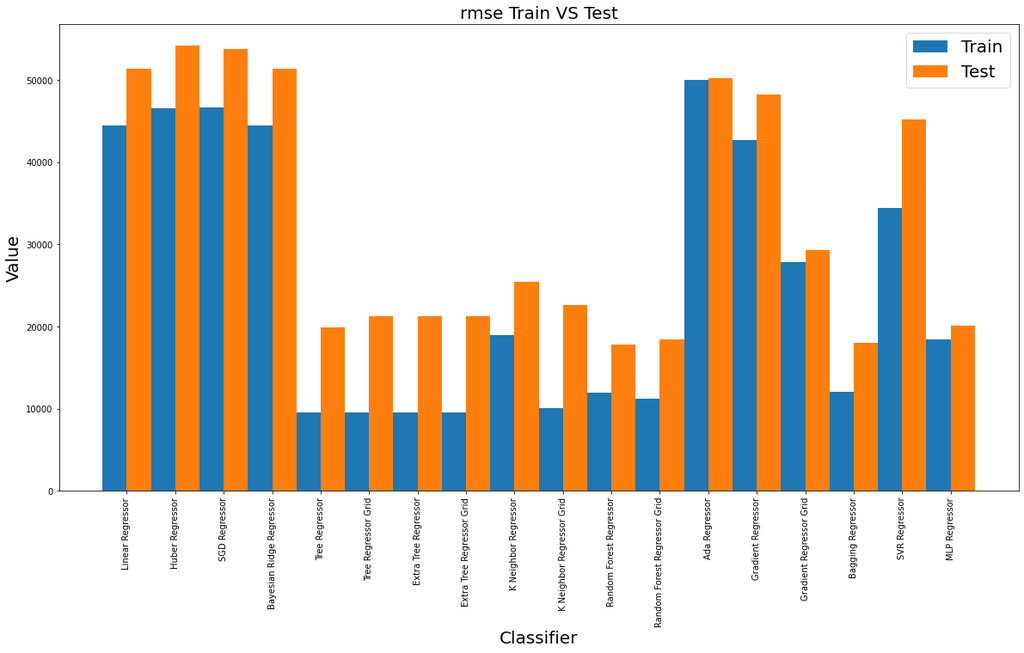

```python
train_rmse = scores_train.rmse.values.tolist()
test_rmse = scores_test.rmse.values.tolist()

fig, ax = plt.subplots(figsize=(20,10))
width = 0.50
i = np.arange(len(train_rmse))
train_bars = ax.bar(i, train_rmse , width,)
test_bars = ax.bar(i+width, test_rmse , width)

ax.set_xlabel("Classifier",fontsize=20)

ax.set_ylabel('Value',fontsize=20)
ax.set_title('rmse Train VS Test',fontsize=20)
ax.set_xticklabels(scores_train.Classifier, rotation = 90)
ax.set_xticks(i + width / 2)

ax.legend((train_bars,test_bars),('Train','Test'),fontsize=20)
plt.show()
```

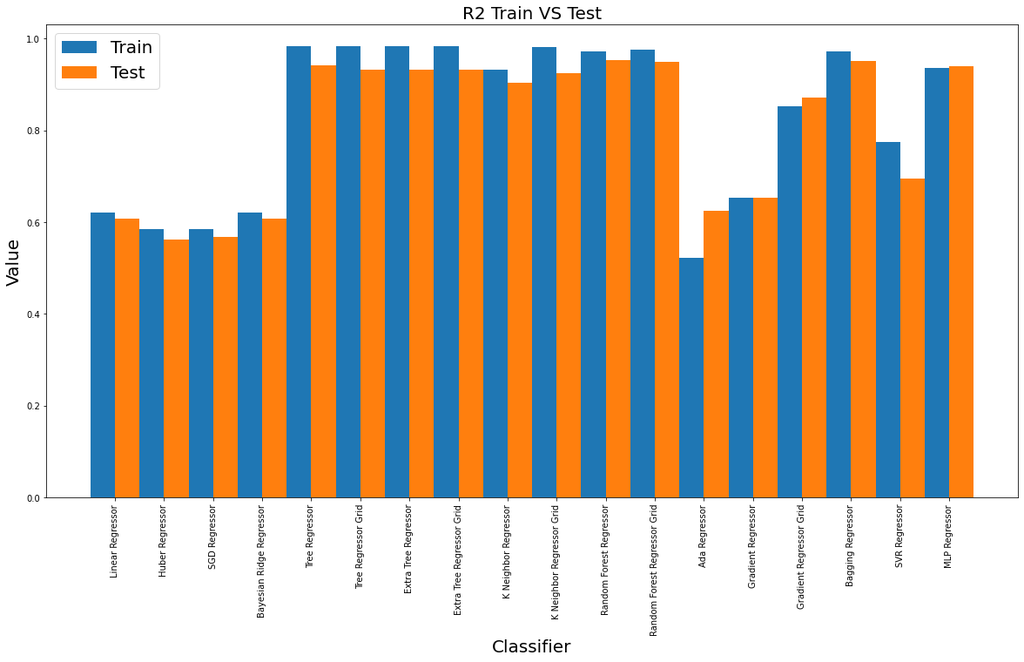

```python
train_r2 = scores_train.r2.values.tolist()
test_r2 = scores_test.r2.values.tolist()

fig, ax = plt.subplots(figsize=(20,10))
width = 0.50
i = np.arange(len(train_r2))
train_bars = ax.bar(i, train_r2 , width,)
test_bars = ax.bar(i+width, test_r2 , width)

ax.set_xlabel("Classifier",fontsize=20)

ax.set_ylabel('Value',fontsize=20)
ax.set_title('R2 Train VS Test',fontsize=20)
ax.set_xticklabels(scores_train.Classifier, rotation = 90)
ax.set_xticks(i + width / 2)

ax.legend((train_bars,test_bars),('Train','Test'),fontsize=20)
plt.show()
```

Riportando i valori su una scala diversa si nota di come gli errori aumentano poichè si sta considerando un intervallo molto più ampio il che rende più difficile avere errori molto piccoli con i dati a disposizione. Nonostante ciò il valore dell'r2 score rimane molto alto e differisce di pochissimo da quello del train set.

Si notano dei miglioramenti da parte degli algoritmi K Neighbor e Gradient Regressor ottimizzati con Grid Search

Per una migliore comprensione dei risultati ottenuti si procede con la visualizzazione della posizione media dei like e la media degli errori rispetto alla distribuzione dei like.

```python
df_final.describe()
```

|  | views | likes | dislikes | comment_count | comments_disabled | ratings_disabled | video_error_or_removed | no_tags | desc_length | trending days_difference | title_length | uppercase_count | special_char | publish_hour |
| --- | --- | --- | --- | --- | --- | --- | --- | --- | --- | --- | --- | --- | --- | --- |
| count | 36573.00000000 | 36573.00000000 | 36573.00000000 | 36573.00000000 | 36573.00000000 | 36573.00000000 | 36573.00000000 | 36573.00000000 | 36573.00000000 | 36573.00000000 | 36573.00000000 | 36573.00000000 | 36573.00000000 | 36573.00000000 |
| mean | 1210975.36116807 | 43114.07191097 | 1685.44603943 | 4977.30629153 | 0.01539387 | 0.00385530 | 0.00054685 | 20.02780740 | 1048.47081180 | 4.72889837 | 48.89150466 | 10.28239412 | 48.87660296 | 13.80534821 |
| std | 1601517.44007708 | 80726.72951976 | 3733.05128653 | 12157.48092485 | 0.12311504 | 0.06197213 | 0.02337878 | 11.89920242 | 855.07817438 | 3.59745430 | 19.65702272 | 8.85797535 | 19.69089037 | 6.44245528 |
| min | 549.00000000 | 0.00000000 | 0.00000000 | 0.00000000 | 0.00000000 | 0.00000000 | 0.00000000 | 1.00000000 | 3.00000000 | 0.00000000 | 3.00000000 | 0.00000000 | 0.00000000 | 0.00000000 |
| 25% | 228745.00000000 | 5191.00000000 | 189.00000000 | 582.00000000 | 0.00000000 | 0.00000000 | 0.00000000 | 10.00000000 | 436.00000000 | 2.00000000 | 34.00000000 | 5.00000000 | 34.00000000 | 11.00000000 |
| 50% | 606446.00000000 | 16160.00000000 | 570.00000000 | 1682.00000000 | 0.00000000 | 0.00000000 | 0.00000000 | 19.00000000 | 851.00000000 | 4.00000000 | 47.00000000 | 8.00000000 | 47.00000000 | 15.00000000 |
| 75% | 1494215.00000000 | 45386.00000000 | 1591.00000000 | 4721.00000000 | 0.00000000 | 0.00000000 | 0.00000000 | 29.00000000 | 1394.00000000 | 7.00000000 | 61.00000000 | 12.00000000 | 61.00000000 | 18.00000000 |
| max | 9998724.00000000 | 1731826.00000000 | 66251.00000000 | 383762.00000000 | 1.00000000 | 1.00000000 | 1.00000000 | 69.00000000 | 5123.00000000 | 15.00000000 | 100.00000000 | 77.00000000 | 100.00000000 | 23.00000000 |

```python
rmse_mean = np.mean(test_rmse)
```

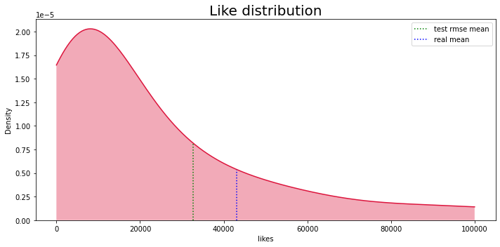

```
rmse_mean:  32759.88656724823
real_mean:  43114.071910972576
```

```python
import matplotlib.patches as mpatches
import matplotlib.lines as mlines

fig, ax = plt.subplots(figsize=(10,5))

ax = sns.kdeplot(df_final['likes'], shade=False, color='crimson',clip=(0.0, 100000.0))
kdeline = ax.lines[0]
rmse_mean = rmse_mean
xs = kdeline.get_xdata()
ys = kdeline.get_ydata()
height = np.interp(rmse_mean, xs, ys)
a = ax.vlines(rmse_mean, 0, height, color='green', ls=':')
ax.fill_between(xs, 0, ys, facecolor='crimson', alpha=0.2)

real_mean = df_final['likes'].mean()
xs = kdeline.get_xdata()
ys = kdeline.get_ydata()
height = np.interp(real_mean, xs, ys)
ax.vlines(real_mean, 0, height, color='blue', ls=':')
ax.fill_between(xs, 0, ys, facecolor='crimson', alpha=0.2)


ax.set_title('Like distribution',fontsize=20)

#ax.legend((mse,mean),('mse','mean'),fontsize=20)
#plt.legend()
mean_patch = mlines.Line2D([],[],color='blue', label='real mean',ls = ':')
mse_patch = mlines.Line2D([],[],color='green', label='test rmse mean',ls = ':')
plt.legend(handles=[mse_patch, mean_patch])
plt.tight_layout()
plt.show()

print("rmse_mean: ", rmse_mean)
print("real_mean: ", real_mean)
```

Dal grafico si nota che la media degli errori è di 32759 ed è posta a sinistra rispetto alla media dei like reali che è pari a 43114.